# Gráficos do Capítulo 4

João Gabriel

2023-05-03

# 1 Gráficos do capítulo 4

Nesse capítulo aprendemos novas funções do ggplot, como o facet_wrap. As utilizações desses novos comandos são diversas e permitem a criação de gráficos muito mais customizados e bem separados.

O primeiro gráfico é uma linha do tempo que mostra a variação do PIB per capita ao longo do tempo. Utilizei a função geom_line para traçar a linha e adicionei rótulos aos eixos x e y, bem como um título para o gráfico. Ainda assim, é muito ruim esse gráfico, não funciona bem.

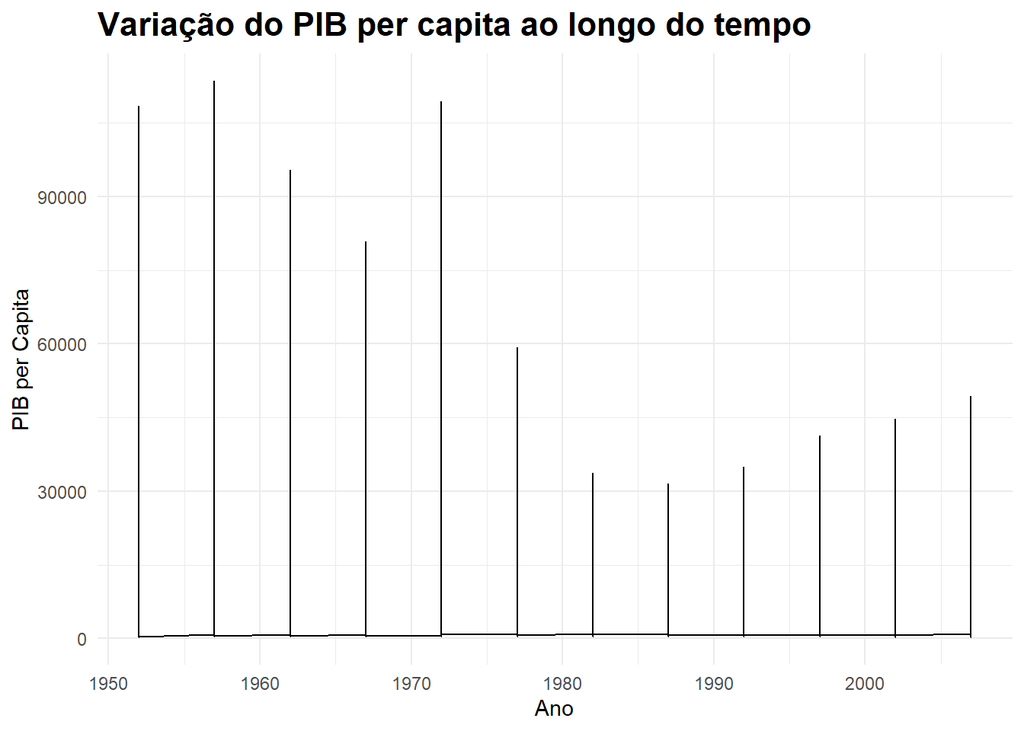

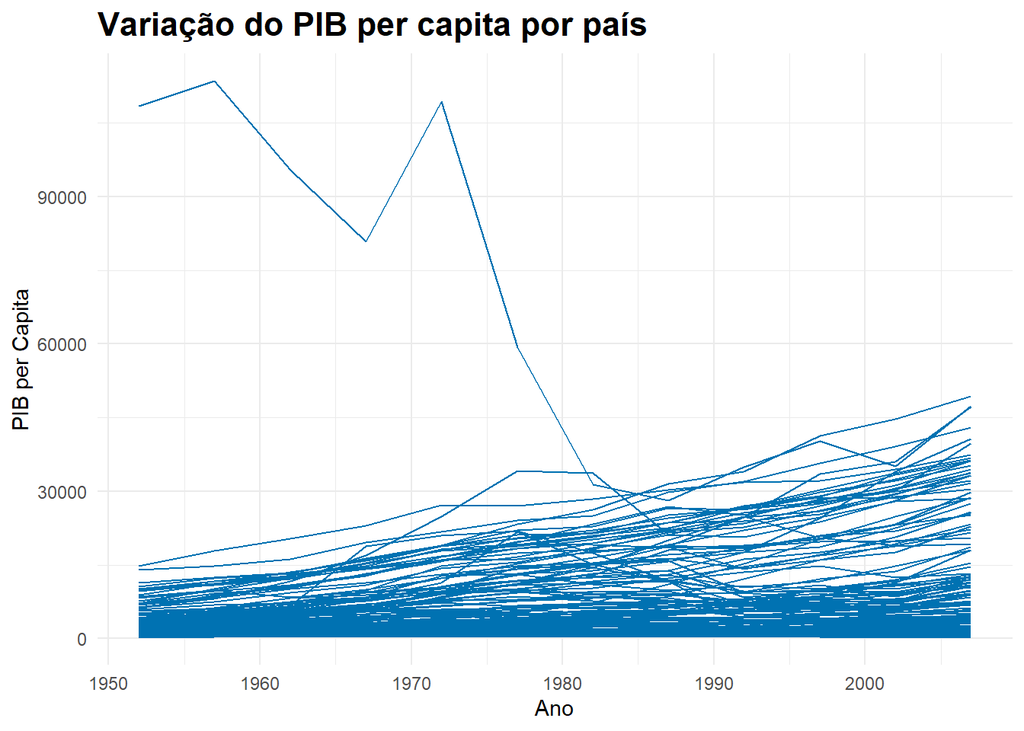

O terceiro gráfico divide os dados por continente usando a função facet_wrap. Cada continente é mostrado em uma subtrama separada, permitindo a comparação da variação do PIB per capita entre continentes.

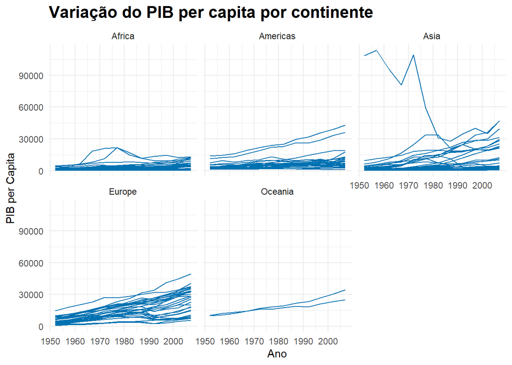

O quarto gráfico também divide os dados por continente, mas utiliza escala logarítmica no eixo y com a função scale_y_log10 para melhor visualização da diferença entre os valores. Além disso, foi adicionada uma linha suavizada usando geom_smooth para indicar a tendência geral dos dados.

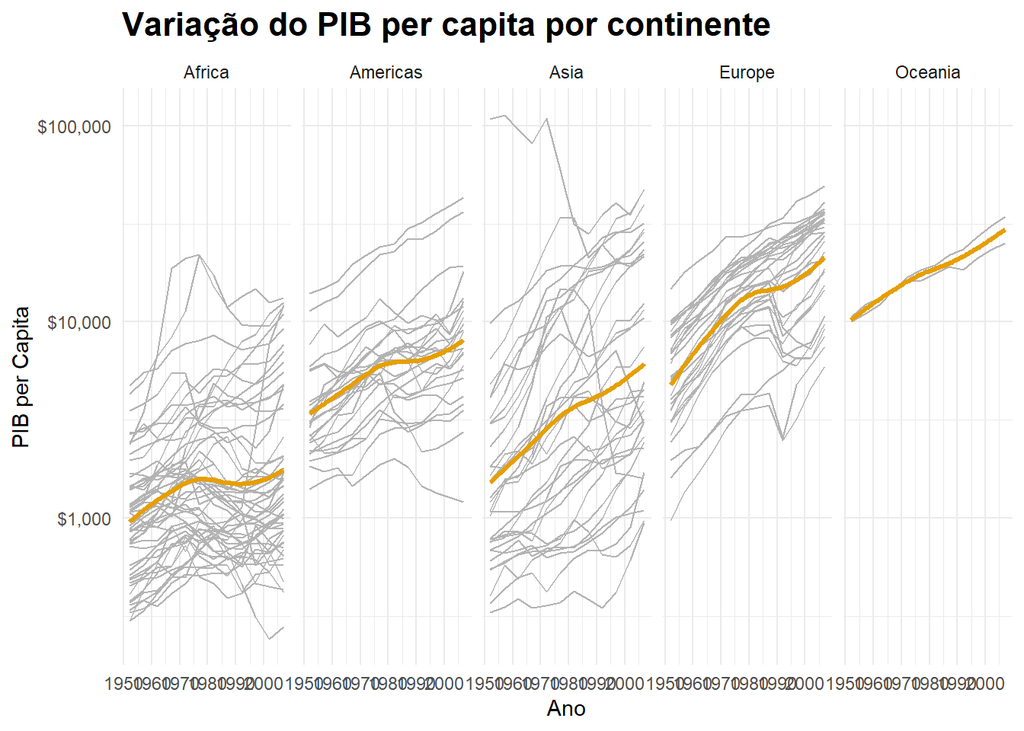

O quinto gráfico mostra a relação entre idade e número de filhos, com diferentes painéis para cada combinação de sexo e raça. Utilizei pontos transparentes (geom_point(alpha = 0.2)) e uma linha de tendência suavizada (geom_smooth) para visualizar a relação geral.

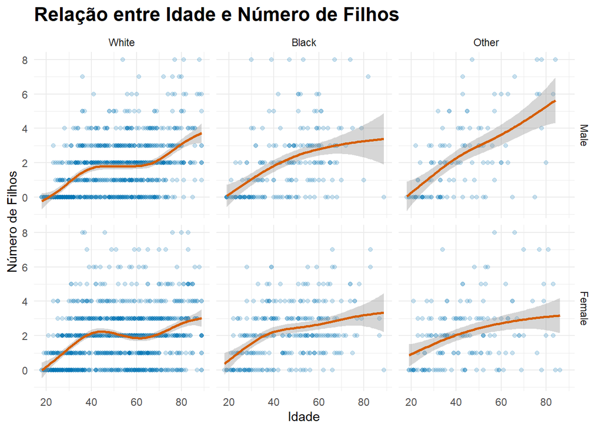

O sexto gráfico é um histograma que mostra a distribuição da contagem de dados por região. Utilizei a função geom_bar para criar o histograma e personalizei os rótulos dos eixos e o título do gráfico.

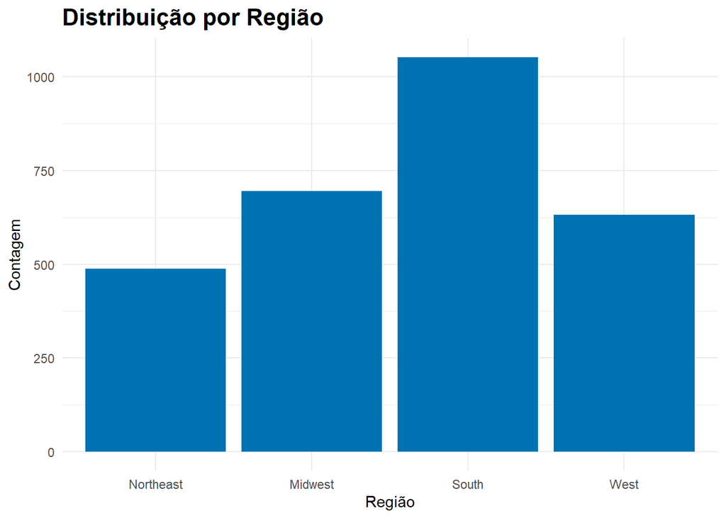

O sétimo gráfico é semelhante ao sexto, mas agrupa os dados por religião. Utilizei geom_bar e removi a legenda de cores com guides(fill = FALSE).

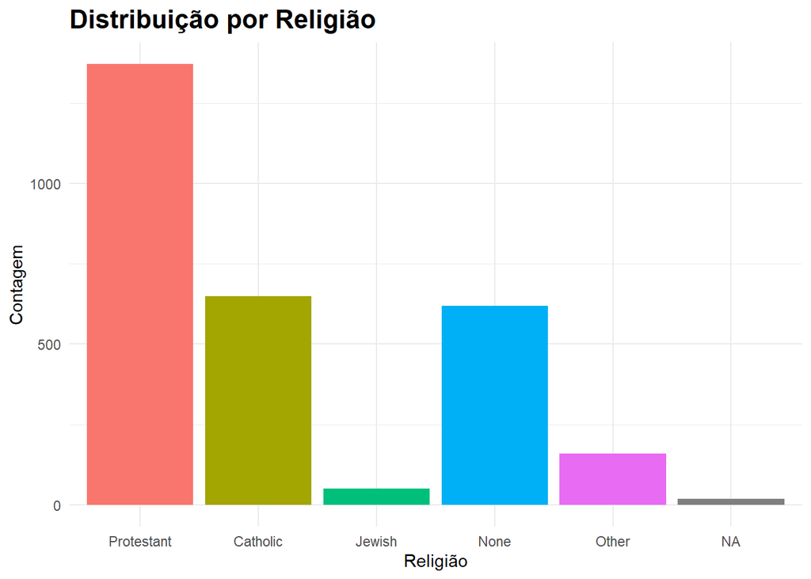

O oitavo gráfico combina os dados de religião e região, mostrando a distribuição da contagem para cada combinação. Utilizei geom_bar e personalizei os rótulos dos eixos e o título do gráfico.

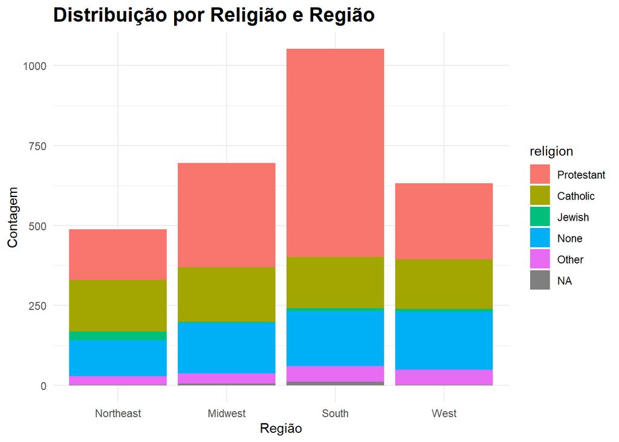

O nono gráfico é uma versão proporcional do oitavo gráfico, onde a altura das barras representa a proporção em vez da contagem. Utilizei geom_bar(position = “fill”) para ajustar as alturas das barras proporcionalmente.

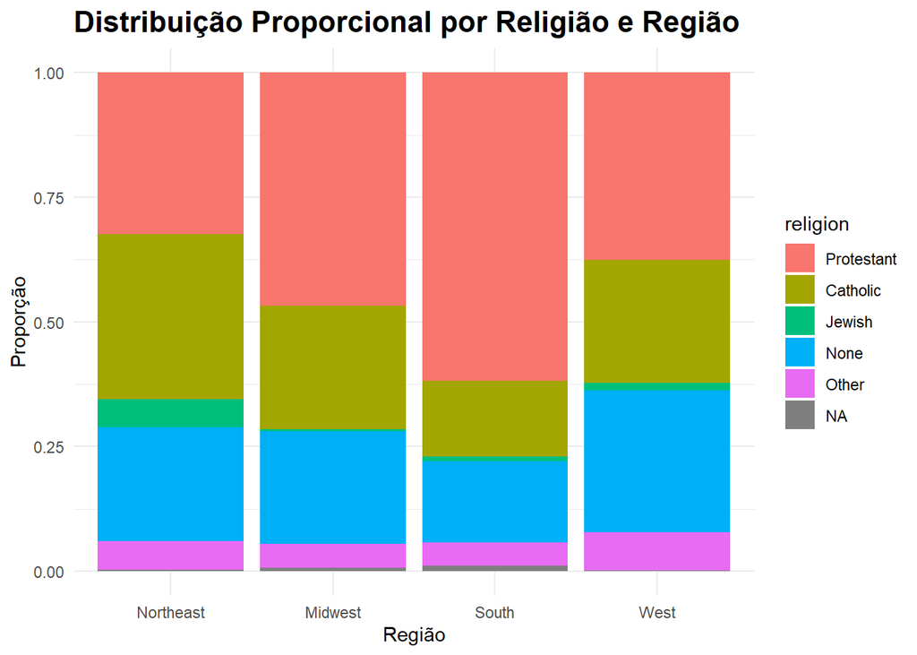

O décimo gráfico é uma variação do nono, onde as barras são agrupadas por religião e separadas por região. Utilizei geom_bar(position = “dodge”) para criar grupos de barras lado a lado.

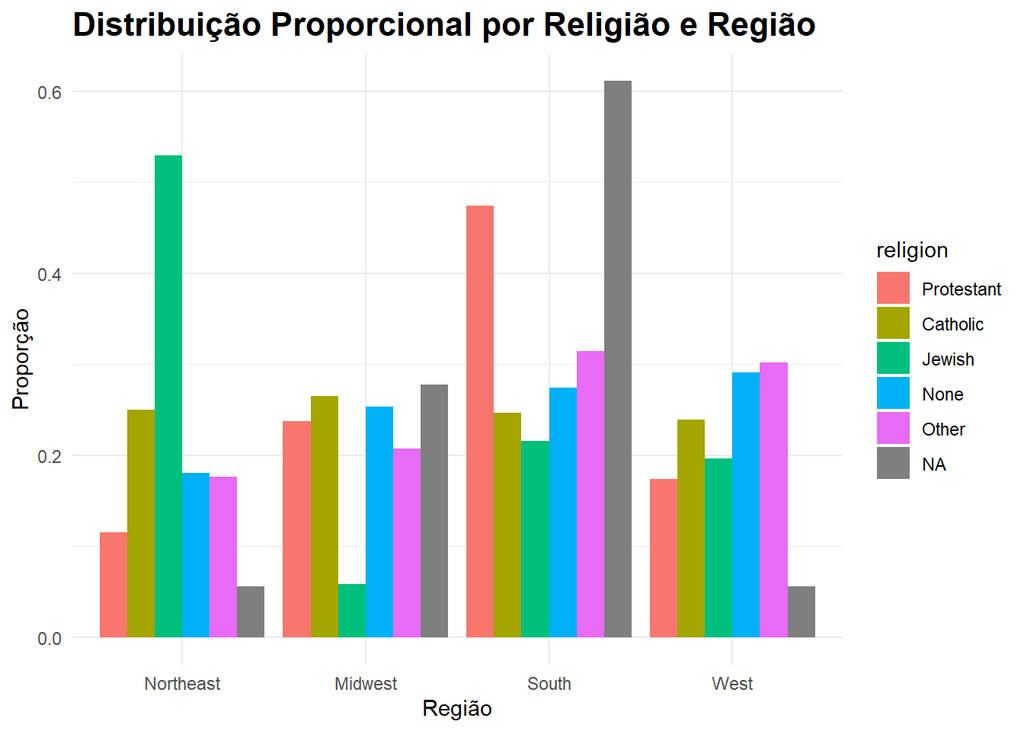

O décimo primeiro gráfico é uma versão do décimo gráfico, mas com painéis separados para cada região. Utilizei facet_wrap para criar os painéis e geom_bar(position = “dodge”) para agrupar as barras.

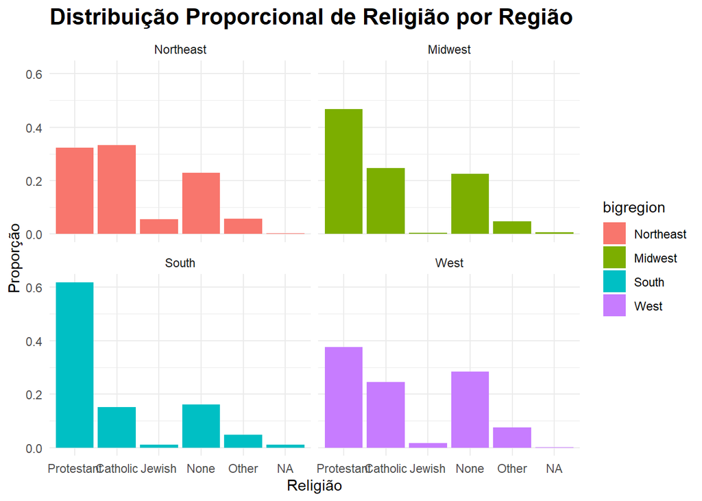

O décimo segundo gráfico é um histograma que mostra a distribuição da área por estado. Utilizei geom_histogram com bins = 10 para criar os histogramas e personalizei os rótulos dos eixos e o título do gráfico.

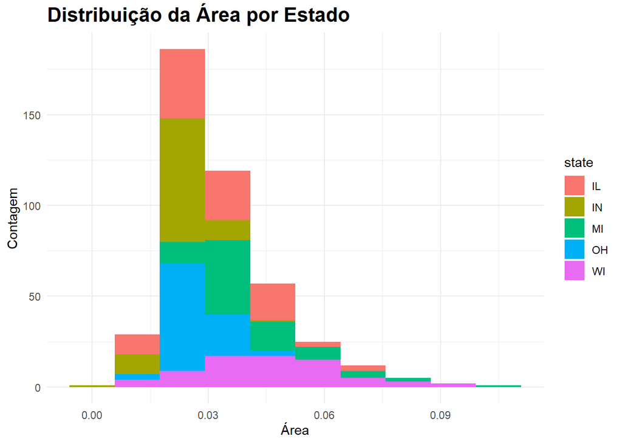

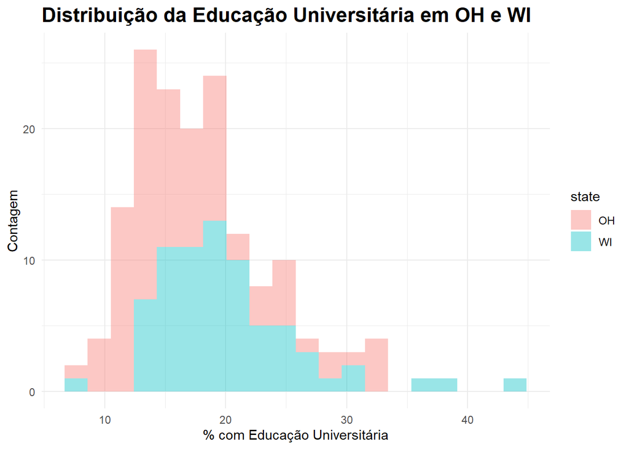

O décimo quarto gráfico é uma estimativa da densidade da distribuição da área. Utilizei geom_density para criar uma curva de densidade e personalizei os rótulos dos eixos e o título do gráfico.

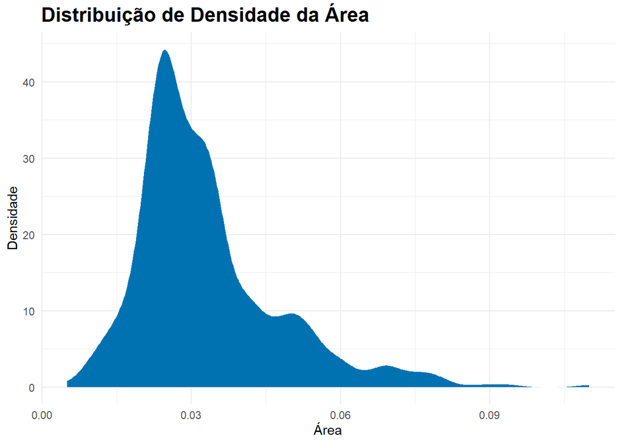

O décimo quinto gráfico é semelhante ao décimo quarto, mas com cores e linhas diferentes para cada estado. Utilizei geom_density e personalizei os rótulos dos eixos e o título do gráfico.

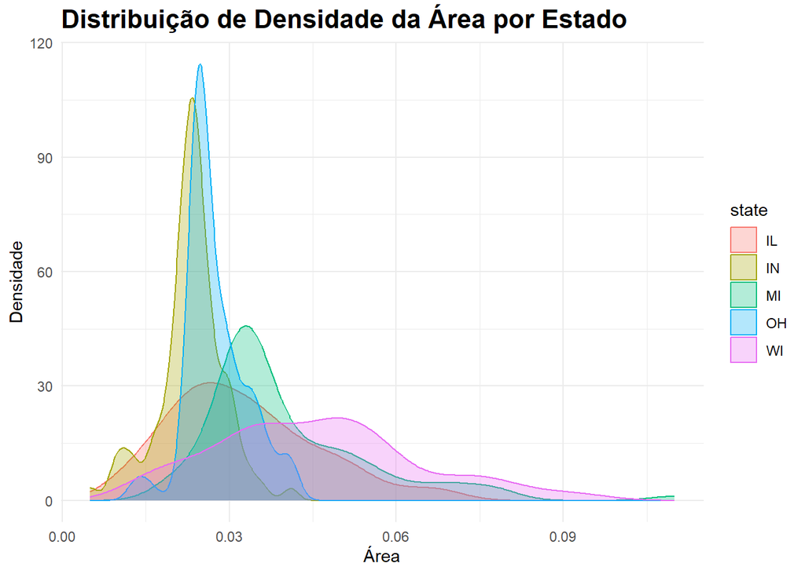

O décimo sexto gráfico é uma versão normalizada do décimo quinto gráfico, onde as densidades são escalonadas para melhor comparação entre os estados. Utilizei geom_density com aes(y = ..scaled..) e personalizei os rótulos dos eixos e o título do gráfico.

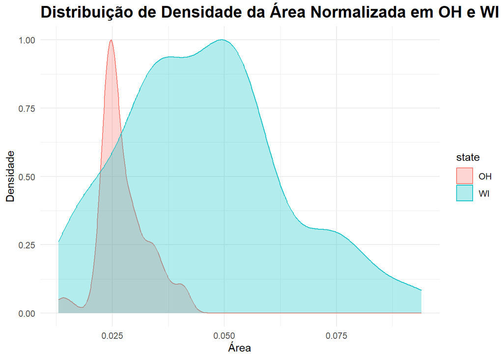

O décimo sétimo gráfico é um gráfico de barras que mostra a distribuição percentual de sobreviventes do Titanic por gênero. Utilizei geom_bar com position = “dodge” e personalizei os rótulos dos eixos e o título do gráfico.

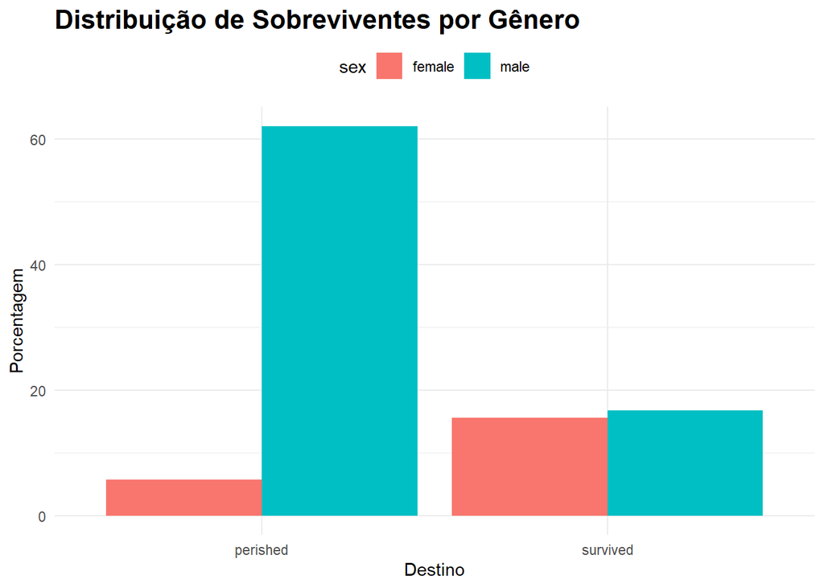

O décimo oitavo gráfico é um gráfico de colunas que mostra a diferença na expectativa de vida americana em relação à média da OECD ao longo do tempo. Utilizei geom_col para criar as colunas e personalizei os rótulos dos eixos, o título do gráfico e adicionei uma legenda para a cor.

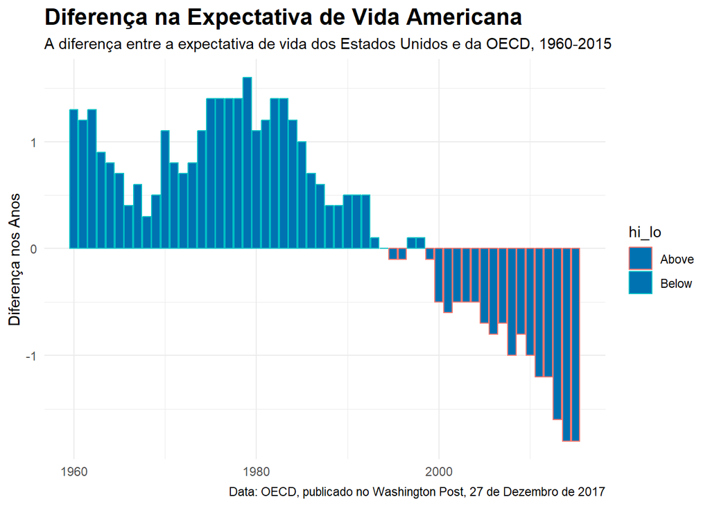

# 2 Gráficos do capítulo 5

No capítulo cinco focamos no tidyverse em geral, principalmente no dplyr. Aprendemos a usar pipes e manipulamos dados para criarmos gráficos diferentes. Os dados desse capítulo são bem variados.

```
## # A tibble: 24 × 5
## # Groups:   bigregion [4]
##    bigregion religion       N    freq   pct
##    <fct>     <fct>      <int>   <dbl> <dbl>
##  1 Northeast Protestant   158 0.324      32
##  2 Northeast Catholic     162 0.332      33
##  3 Northeast Jewish        27 0.0553      6
##  4 Northeast None         112 0.230      23
##  5 Northeast Other         28 0.0574      6
##  6 Northeast <NA>           1 0.00205     0
##  7 Midwest   Protestant   325 0.468      47
##  8 Midwest   Catholic     172 0.247      25
##  9 Midwest   Jewish         3 0.00432     0
## 10 Midwest   None         157 0.226      23
## # … with 14 more rows
```

```
## # A tibble: 4 × 2
##   bigregion total
##   <fct>     <dbl>
## 1 Northeast   100
## 2 Midwest     101
## 3 South       100
## 4 West        101
```

```
## # A tibble: 24 × 5
## # Groups:   bigregion [4]
##    bigregion religion       N    freq   pct
##    <fct>     <fct>      <int>   <dbl> <dbl>
##  1 Northeast Protestant   158 0.324      32
##  2 Northeast Catholic     162 0.332      33
##  3 Northeast Jewish        27 0.0553      6
##  4 Northeast None         112 0.230      23
##  5 Northeast Other         28 0.0574      6
##  6 Northeast <NA>           1 0.00205     0
##  7 Midwest   Protestant   325 0.468      47
##  8 Midwest   Catholic     172 0.247      25
##  9 Midwest   Jewish         3 0.00432     0
## 10 Midwest   None         157 0.226      23
## # … with 14 more rows
```

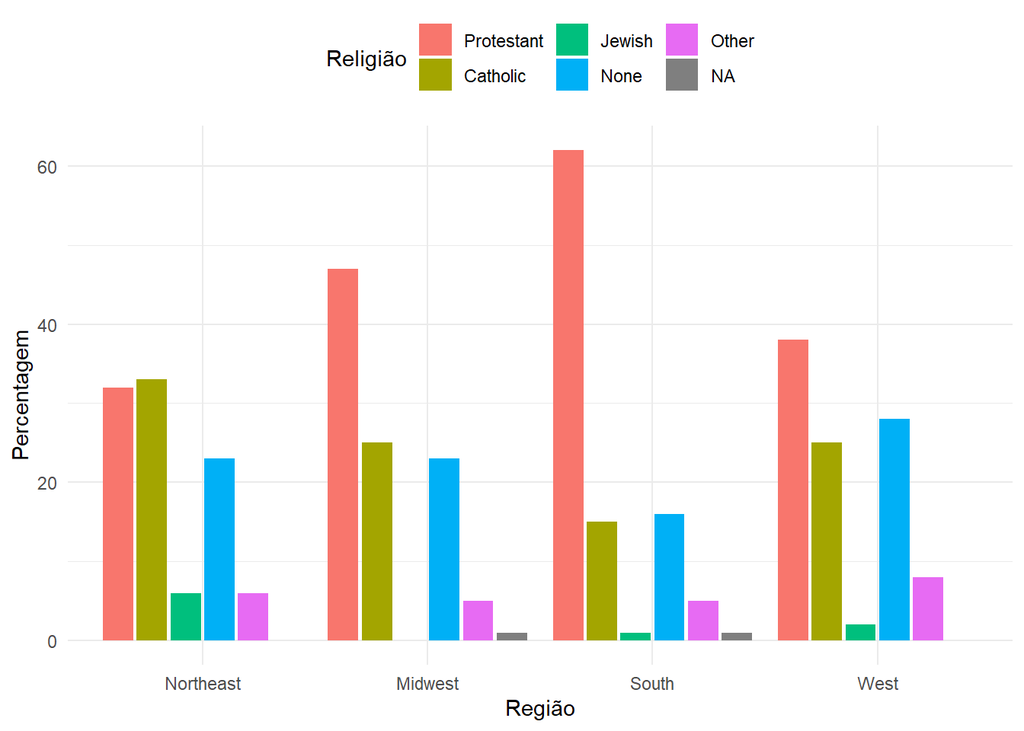

Este gráfico de barras agrupadas mostra a distribuição da frequência das religiões em diferentes regiões. O eixo x representa a região e o eixo y representa a porcentagem de ocorrência de cada religião. A função geom_col é utilizada para criar as barras agrupadas. A legenda é posicionada na parte superior do gráfico utilizando theme(legend.position = “top”).

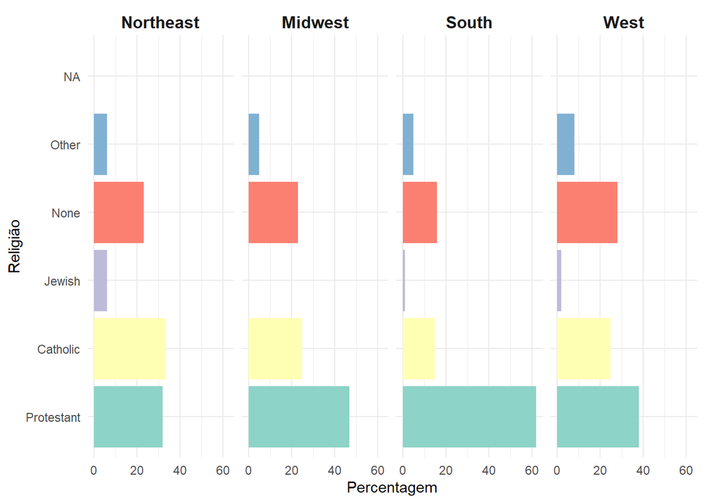

Este gráfico de barras agrupadas mostra a distribuição da frequência das religiões em diferentes regiões, mas com os eixos x e y trocados em relação ao gráfico anterior. A função coord_flip é utilizada para inverter os eixos. O gráfico é facetado por região utilizando a função facet_grid. A escala de cores é definida utilizando a paleta “Set3” da função scale_fill_brewer.

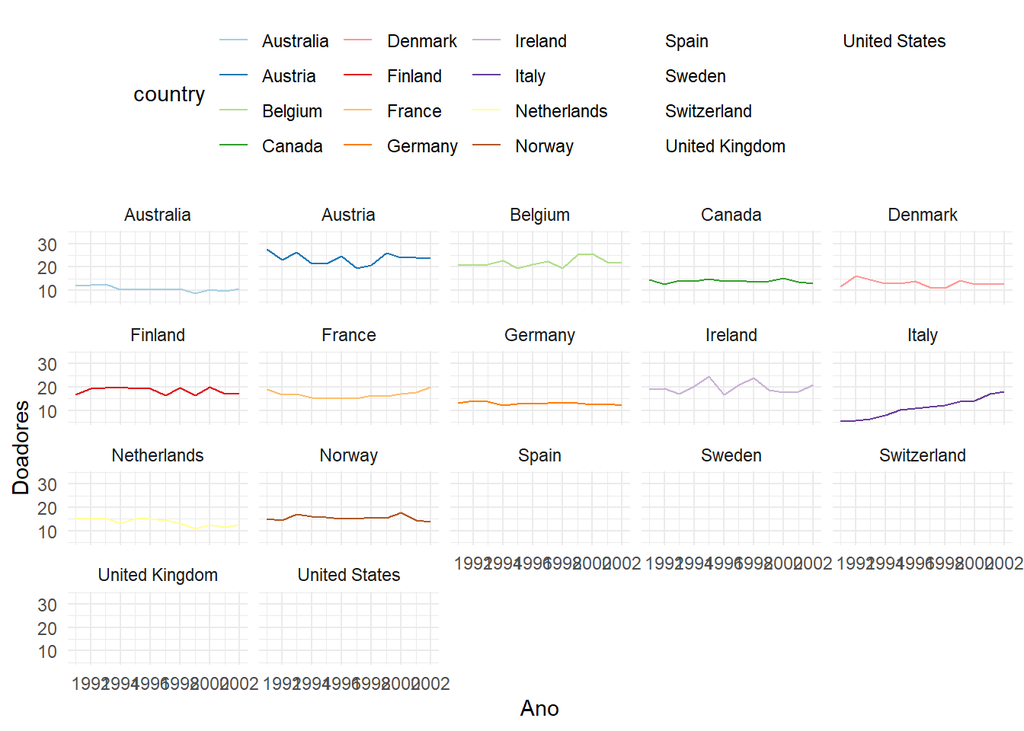

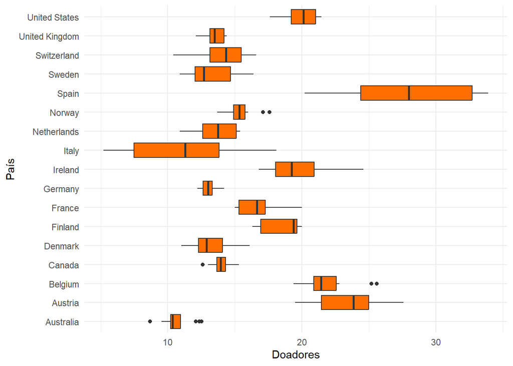

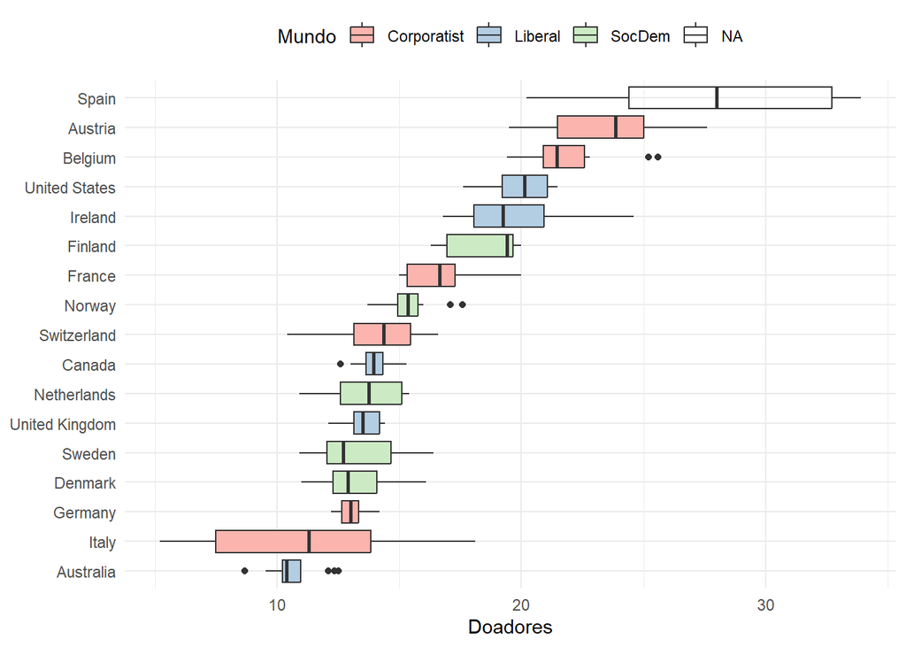

Este gráfico de boxplot mostra a distribuição dos números de doadores de órgãos por país, com os países ordenados de acordo com a mediana do número de doadores. A função reorder é utilizada para reordenar os países. A paleta de cores “Pastel1” é usada para deixar mais bonito o gráfico.

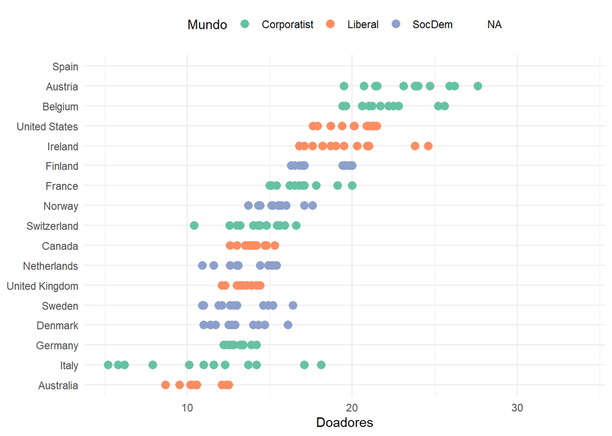

Este gráfico de dispersão mostra o número de doadores de órgãos por país, com os países ordenados de acordo com o número de doadores. A função reorder é utilizada para reordenar os países. A legenda de cores é definida utilizando scale_color_brewer(palette = “Set2”).

```
## # A tibble: 17 × 8
## # Groups:   consent_law [2]
##    consent_law country        donors_m…¹ donor…² gdp_m…³ healt…⁴ roads…⁵ cereb…⁶
##    <chr>       <chr>               <dbl>   <dbl>   <dbl>   <dbl>   <dbl>   <dbl>
##  1 Informed    Australia            10.6   1.14    1958.   1958.   105.     558.
##  2 Informed    Canada               14.0   0.751   2272.   2272.   109.     422.
##  3 Informed    Denmark              13.1   1.47    2054.   2054.   102.     641.
##  4 Informed    Germany              13.0   0.611   2349.   2349.   113.     707.
##  5 Informed    Ireland              19.8   2.48    1480.   1480.   118.     705.
##  6 Informed    Netherlands          13.7   1.55    1993.   1993.    76.1    585.
##  7 Informed    United Kingdom       13.5   0.775   1561.   1561.    67.9    708.
##  8 Informed    United States        20.0   1.33    3988.   3988.   155.     444.
##  9 Presumed    Austria              23.5   2.42    1875.   1875.   150.     769.
## 10 Presumed    Belgium              21.9   1.94    1958.   1958.   155.     594.
## 11 Presumed    Finland              18.4   1.53    1615.   1615.    93.6    771.
## 12 Presumed    France               16.8   1.60    2160.   2160.   156.     433.
## 13 Presumed    Italy                11.1   4.28    1757    1757    122.     712.
## 14 Presumed    Norway               15.4   1.11    2217.   2217.    70.0    662.
## 15 Presumed    Spain                28.1   4.96    1289.   1289.   161.     655.
## 16 Presumed    Sweden               13.1   1.75    1951.   1951.    72.3    595.
## 17 Presumed    Switzerland          14.2   1.71    2776.   2776.    96.4    424.
## # … with abbreviated variable names ¹donors_mean, ²donors_sd, ³gdp_mean,
## #   ⁴health_mean, ⁵roads_mean, ⁶cerebvas_mean
```

```
## # A tibble: 17 × 28
##    consent_law country   donor…¹ pop_m…² pop_d…³ gdp_m…⁴ gdp_l…⁵ healt…⁶ healt…⁷
##    <chr>       <chr>       <dbl>   <dbl>   <dbl>   <dbl>   <dbl>   <dbl>   <dbl>
##  1 Informed    Australia    10.6  18318.   0.237  22179.  21779.   1958.   1848.
##  2 Informed    Canada       14.0  29608.   0.297  23711.  23353.   2272.   2163.
##  3 Informed    Denmark      13.1   5257.  12.2    23722.  23275    2054.   1973.
##  4 Informed    Germany      13.0  80255.  22.5    22163.  21938.   2349.   2256.
##  5 Informed    Ireland      19.8   3674.   5.23   20824.  20154.   1480.   1341.
##  6 Informed    Netherla…    13.7  15548.  37.4    23013.  22554.   1993.   1885.
##  7 Informed    United K…    13.5  58187.  24.0    21359.  20962.   1561.   1464.
##  8 Informed    United S…    20.0 269330.   2.80   29212.  28699.   3988.   3760.
##  9 Presumed    Austria      23.5   7927.   9.45   23876.  23415.   1875.   1803.
## 10 Presumed    Belgium      21.9  10153.  30.7    22500.  22096.   1958.   1862.
## 11 Presumed    Finland      18.4   5112.   1.51   21019.  20763    1615.   1560.
## 12 Presumed    France       16.8  58056.  10.5    22603.  22211.   2160.   2066.
## 13 Presumed    Italy        11.1  57360.  19.0    21554.  21195.   1757    1689.
## 14 Presumed    Norway       15.4   4386.   1.35   26448.  25769.   2217.   2125.
## 15 Presumed    Spain        28.1  39666.   7.84   16933   16584.   1289.   1220.
## 16 Presumed    Sweden       13.1   8789.   1.95   22415.  22094    1951.   1868
## 17 Presumed    Switzerl…    14.2   7037.  17.0    27233   26931.   2776.   2656.
## # … with 19 more variables: pubhealth_mean <dbl>, roads_mean <dbl>,
## #   cerebvas_mean <dbl>, assault_mean <dbl>, external_mean <dbl>,
## #   txp_pop_mean <dbl>, donors_sd <dbl>, pop_sd <dbl>, pop_dens_sd <dbl>,
## #   gdp_sd <dbl>, gdp_lag_sd <dbl>, health_sd <dbl>, health_lag_sd <dbl>,
## #   pubhealth_sd <dbl>, roads_sd <dbl>, cerebvas_sd <dbl>, assault_sd <dbl>,
## #   external_sd <dbl>, txp_pop_sd <dbl>, and abbreviated variable names
## #   ¹donors_mean, ²pop_mean, ³pop_dens_mean, ⁴gdp_mean, ⁵gdp_lag_mean, …
```

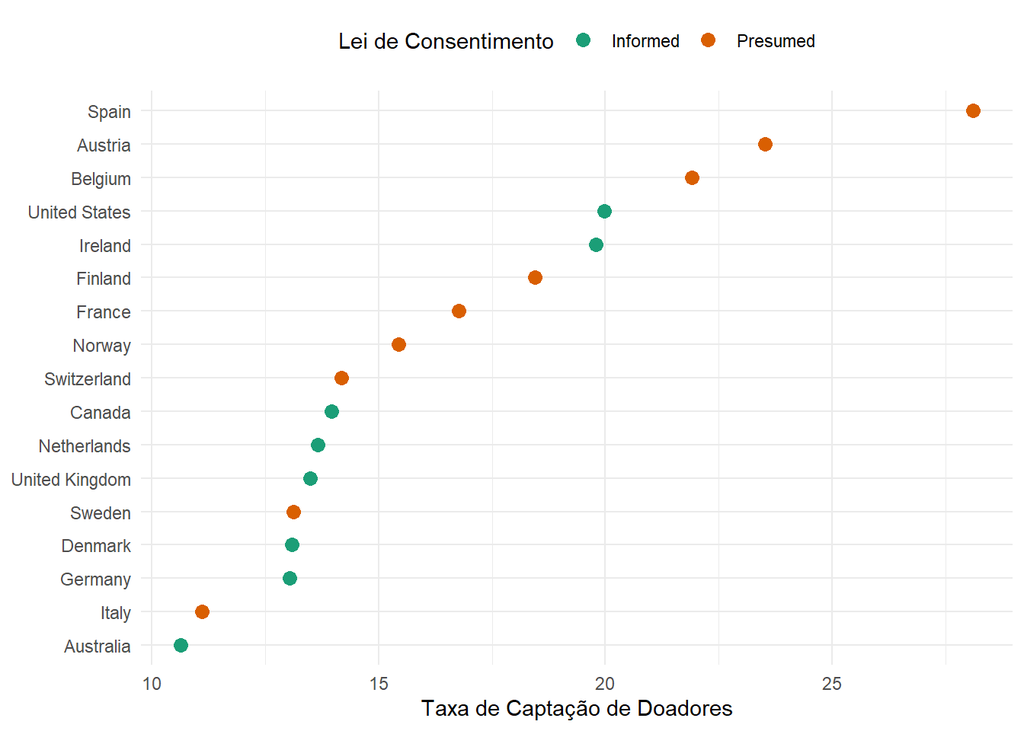

Mostra a taxa de captação de doadores em relação ao país, diferenciando as leis de consentimento através das cores. Utiliza pontos para representar os dados. Coloquei uma paleta de cores e ajustei o tema para deixá-lo mais bonito.

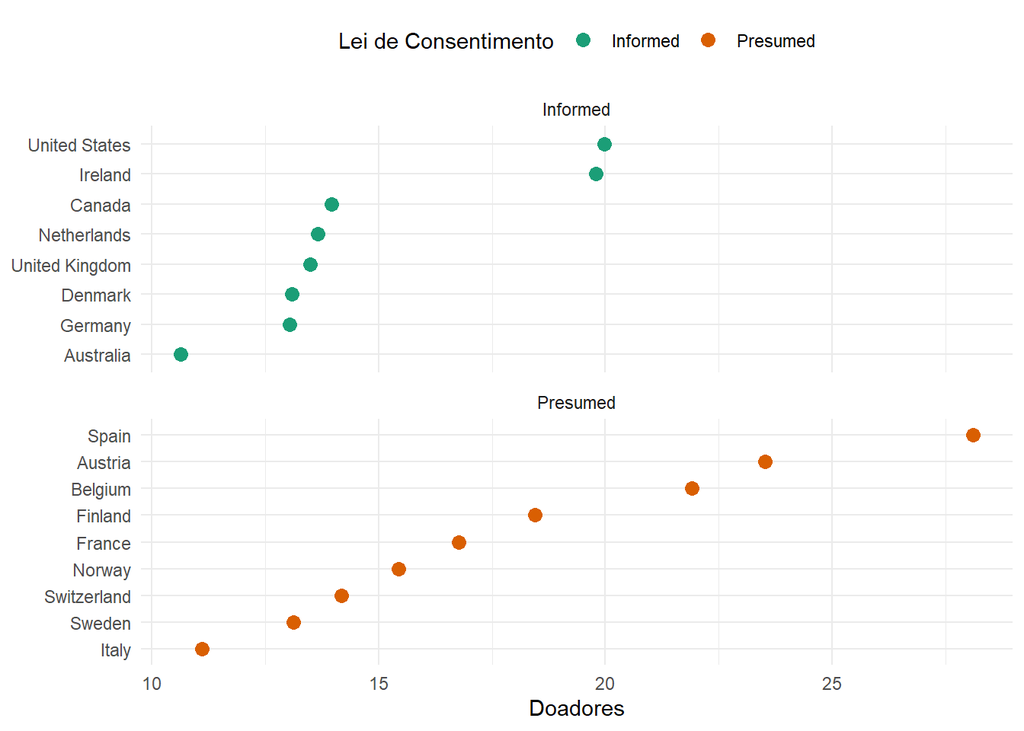

Similar ao Gráfico G, mas com painéis separados por lei de consentimento. Permite comparar a taxa de captação de doadores entre países e leis de consentimento. O mesmo tema foi usado, além dos textos traduzidos.

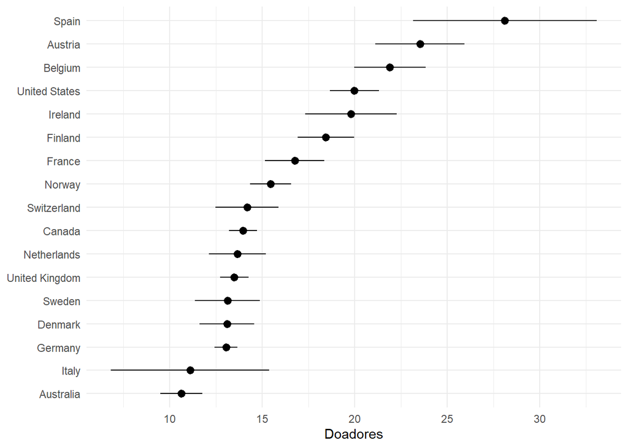

```
## # A tibble: 49 × 6
##     year winner                 win_party ec_pct popular_pct popular_margin
##    <int> <chr>                  <chr>      <dbl>       <dbl>          <dbl>
##  1  1824 John Quincy Adams      D.-R.      0.322       0.309        -0.104
##  2  1828 Andrew Jackson         Dem.       0.682       0.559         0.122
##  3  1832 Andrew Jackson         Dem.       0.766       0.547         0.178
##  4  1836 Martin Van Buren       Dem.       0.578       0.508         0.142
##  5  1840 William Henry Harrison Whig       0.796       0.529         0.0605
##  6  1844 James Polk             Dem.       0.618       0.495         0.0145
##  7  1848 Zachary Taylor         Whig       0.562       0.473         0.0479
##  8  1852 Franklin Pierce        Dem.       0.858       0.508         0.0695
##  9  1856 James Buchanan         Dem.       0.588       0.453         0.122
## 10  1860 Abraham Lincoln        Rep.       0.594       0.396         0.101
## # … with 39 more rows
```

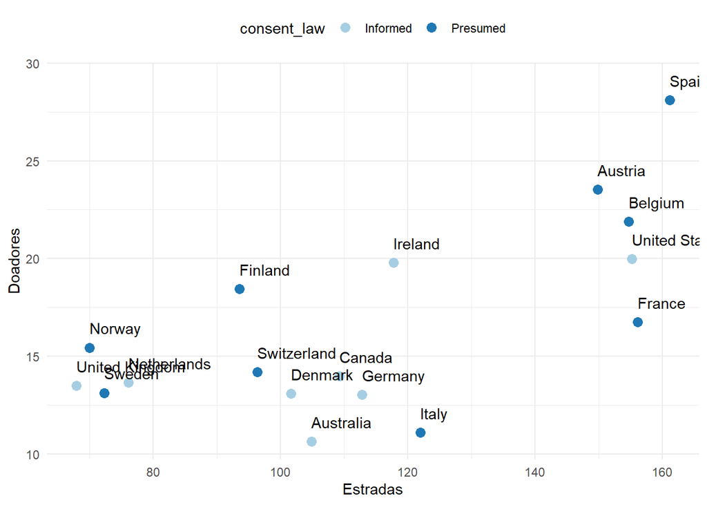

Relaciona o número de estradas com a quantidade de doadores, destacando as leis de consentimento por cores. Cada ponto representa um país. Os títulos e legendas foram salvas em variáveis dessas vez, o que permite melhor controle do código.

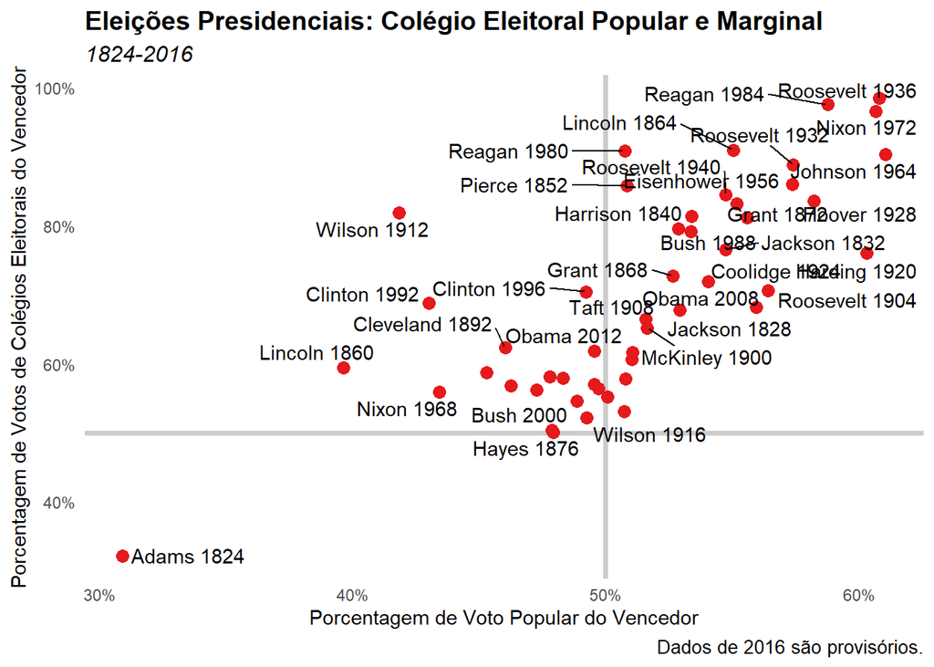

Mostra a relação entre a porcentagem de votos populares e a porcentagem de votos dos colégios eleitorais em eleições presidenciais. Utiliza pontos e rótulos para identificar como os vencedores ganharam a eleição e seu total de votos.

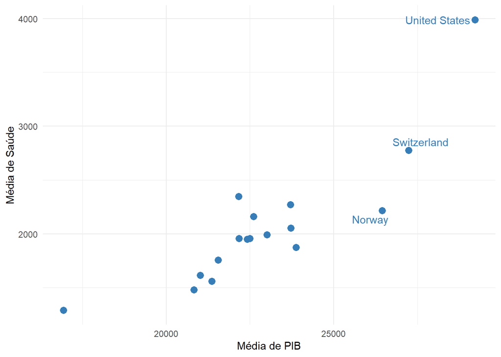

Apresenta a média de PIB em relação à média de saúde por país. Utiliza pontos para representar os dados, com rótulos para países com PIB acima de 25000. Possui uma cor diferenciada e pontos maiores para melhor vizualização.

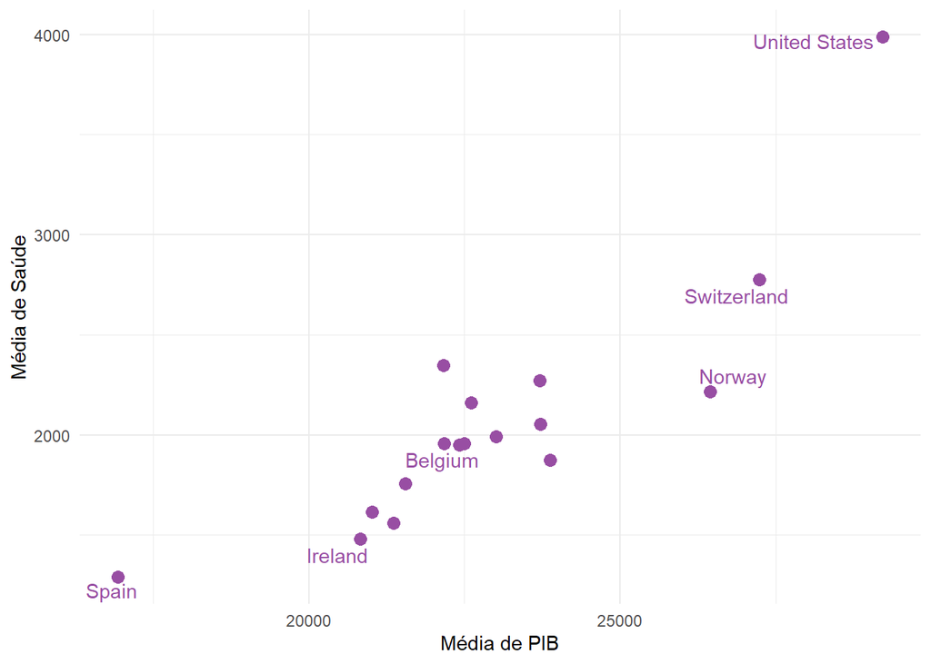

Similar ao Gráfico anterior, mas com mais países destacados devido a critérios específicos (PIB acima de 25000 ou saúde abaixo de 1500 ou apenas ser a Bélgica). Com os destaques, podemos focar na informação que queremos passar

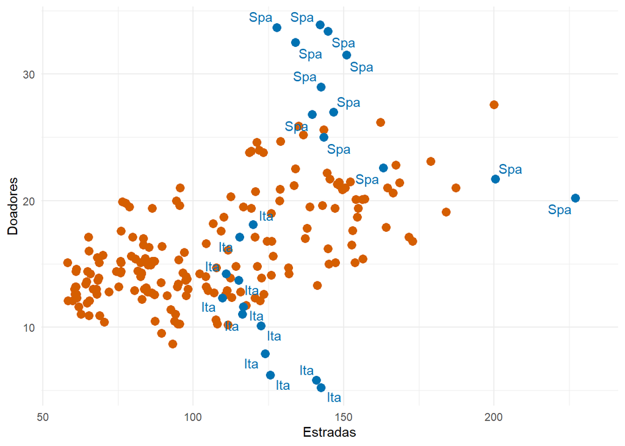

Relaciona o número de estradas com a quantidade de doadores, diferenciando países específicos por cor. Utiliza pontos e rótulos para representar os países. As cores agora foram modificadas para embelezamento.

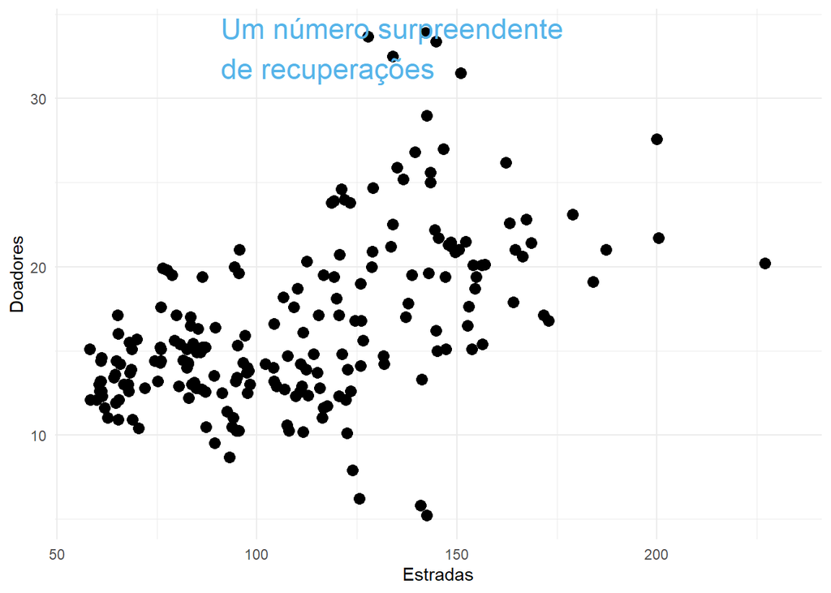

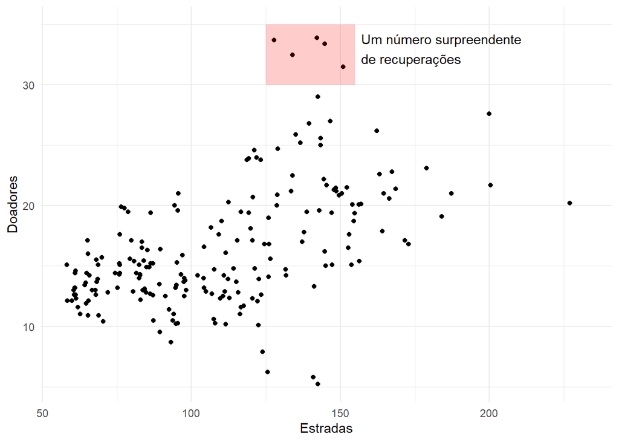

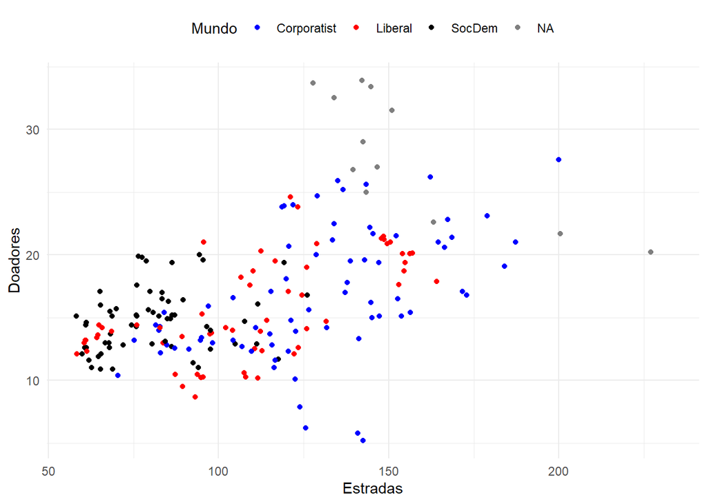

Relaciona o número de estradas com a quantidade de doadores, diferenciando o mundo por cores. Utiliza pontos para representar os dados. As cores foram modificadas e os textos traduzidos.

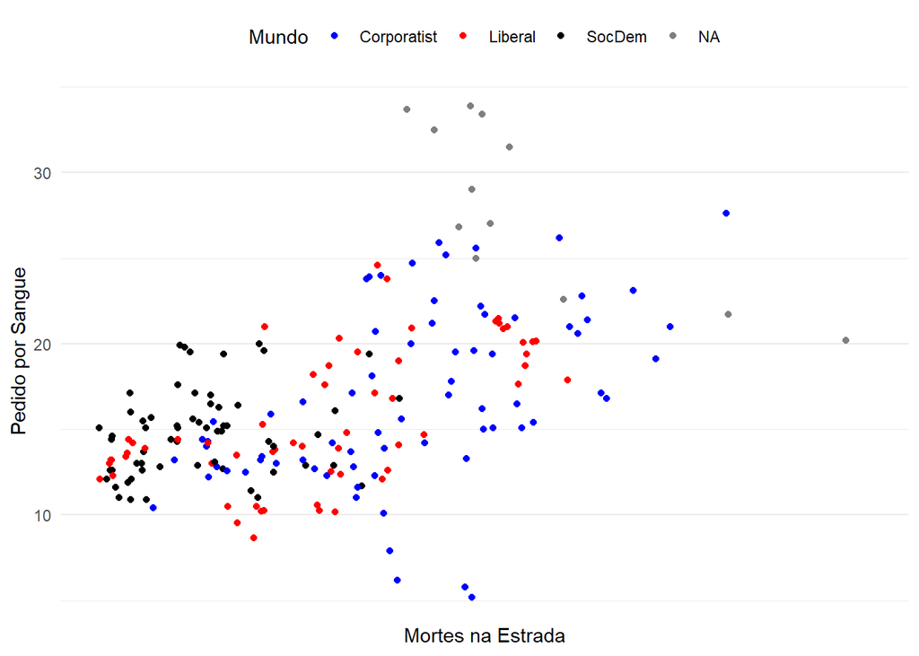

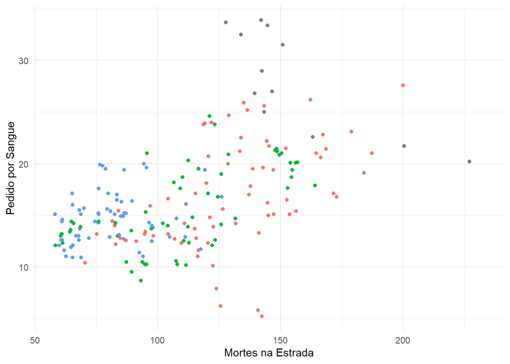

# 3 Conclusão

Foi um trabalho díficil e cheio de detalhes, com muita edição de gráficos e formas de alterá-los, mas foi útil para descobrir ainda mais comandos úteis do ggplot e do tidyverse em geral. Os gráficos com facet_wrap ficam bem interessantes.